# Managing paradoxes through business model design

Ieva Rozentale  
27/09/2018

### Initial research question

How the two orientations [creative and business] of creative enterprises affect the business models that they apply, also over time, and how these business models affect performance?

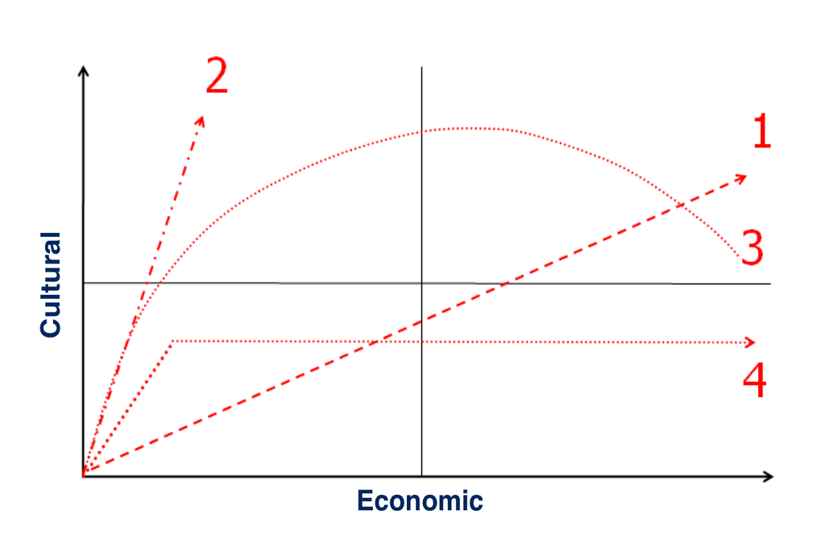

### Adopting a paradox lens

if/if versus both/and

The reformulated research question:

### Three studies

1. When confronted with paradoxical goals, how do firms make decisions about their business models?
2. How do differentiation and integration decisions within different business model elements lead to (mis-) balanced performance in conflicting domains?
3. What combinations of business models and strategic orientations lead to success in both of the conflicting performance domains?

### Study 1: Crafting business models for paradoxical goals

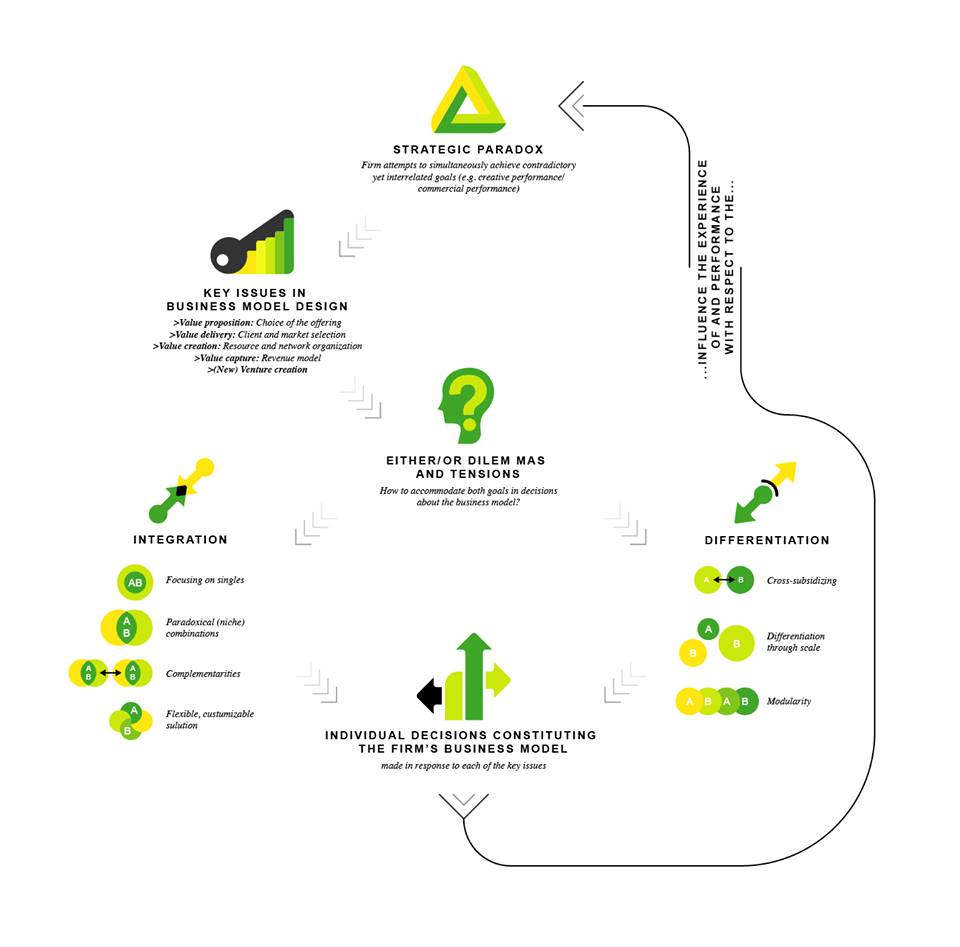

### Study 1: Paradox management tactics

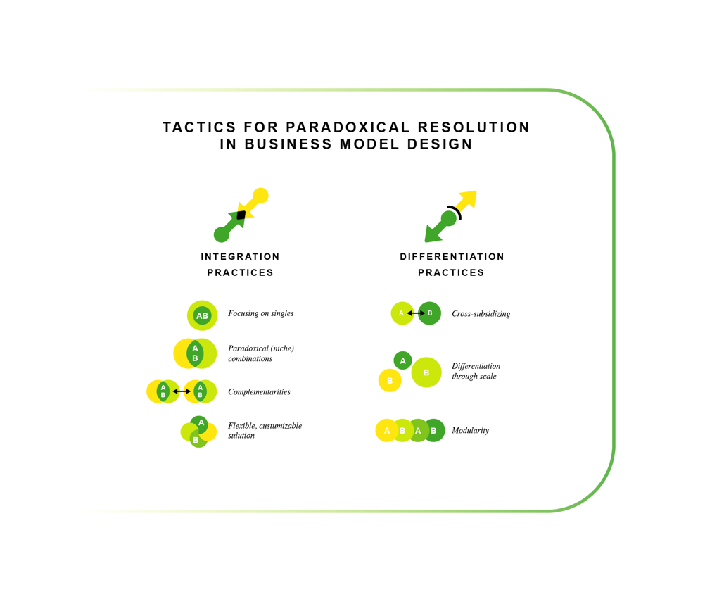

### Study 1: Conclusions

The results invite to:

- connect business model design with “the battle of the souls”
- engage creatively with managing paradoxical goals
- be more conscious of the oppotunities, but also downsides of applying any of the decision-making tactics
- learn from the in-depth accounts of the case study

### Study 2: Killing two birds with one business model

Q: How much can a firm differentiate at the business model, to be successful both creatively and commercially?

## 5 differentiation practices:

Both performance measures high

| Conditions / Sol | 1 | 2 |
| --- | --- | --- |
| VPDIF | ⦻ | ⦻ |
| SEGM | ⦻ | ⚫ |
| NETWDIF |  | ⦻ |
| REVDIF |  | ⚫ |
| SPIN | ⚫ |  |
| Consistency | 0.827 | 0.928 |
| Raw coverage | 0.140 | 0.355 |
| Unique coverage | 0.046 | 0.261 |
| PRI | 0.407 | 0.497 |
| Nr. cases | 6 | 14 |
| Solution consistency | 0.889 |  |
| Solution coverage | 0.401 |  |
| Solution PRI | 0.486 |  |
| Nr. Cases 1/0/C | 20 /157/0 |  |

One or both performance measures low

| Conditions / Sol. | 3 | 4 | 5 | 6 | 7 | 8 |
| --- | --- | --- | --- | --- | --- | --- |
| VPDIF | ⦻ |  |  | ⚫ |  |  |
| SEGM |  | ⦻ | ⚫ |  | ⚫ |  |
| NETWDIF | ⚫ |  |  | ⦻ | ⚫ |  |
| REVDIF |  |  | ⦻ |  | ⚫ | ⦸ |
| SPINDIF |  | ⦻ |  | ⦻ | ⚫ | ⦸ |
| Consistency | 0.869 | 0.779 | 0.829 | 0.859 | 0.833 | 0.751 |
| Raw coverage | 0.379 | 0.442 | 0.461 | 0.394 | 0.184 | 0.502 |
| Unique coverage | 0.042 | 0.030 | 0.084 | 0.028 | 0.050 | 0.033 |
| PRI | 0.210 | 0.152 | 0.367 | 0.295 | 0.193 | 0.523 |
| Nr. cases | 21 | 50 | 30 | 47 | 7 | 77 |
| Solution consistency | 0.713 |  |  |  |  |  |
| Solution coverage | 0.851 |  |  |  |  |  |
| Solution PRI | 0.430 |  |  |  |  |  |
| Nr. Cases 1/0/C | 126/ | 51/ | 0 |  |  |  |

### Study 2: Conclusions

- Anna Karenina principle for success
- Only differentiation or integration does not work - need to mix
- It matters you mix.

### General contributions

- Mapping established and emerging business models in the creative services
- Business models can be used as tools for balancing conflicting performance criteria
- *Business models as practice:* they are actively reconstructed as the managers make decisions about the offering, clients, resources and revenue models
- A need of balancing the balancing act
- Creative versus commercial business models - even more balancing (and simplicity)

### Dissemination

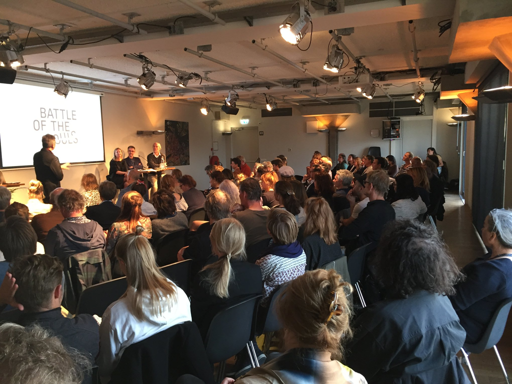

Pahuis de Zwijger

Dude Magazine

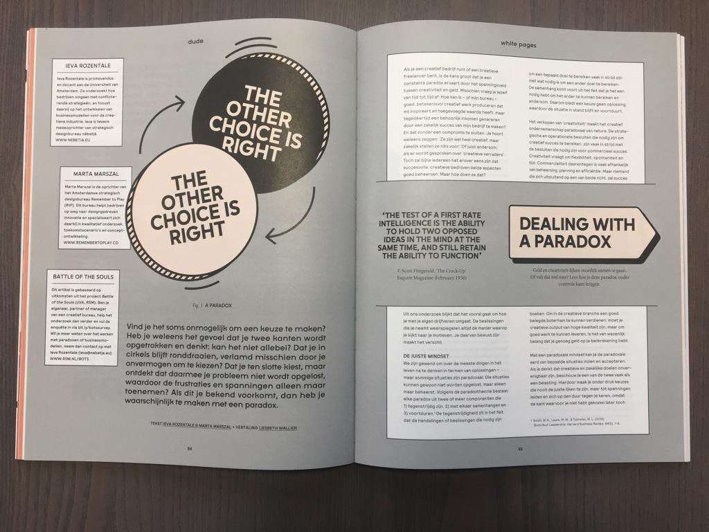

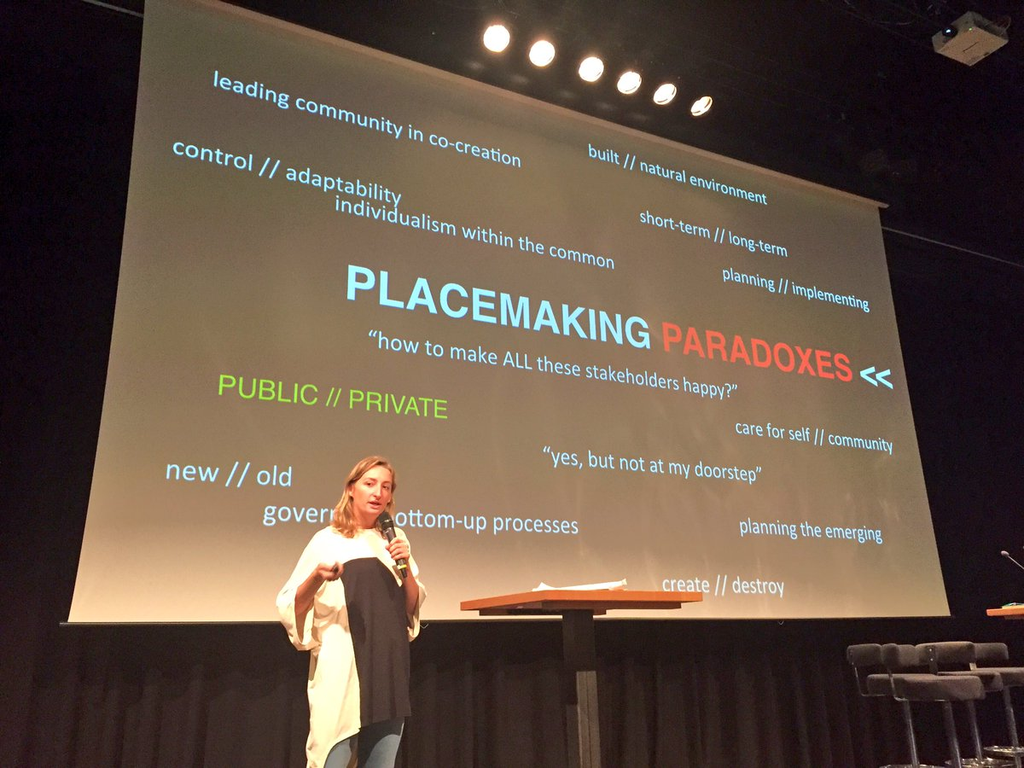

Placemaking Week